# EPF - Electricity Spot Price Forecasting

## 2021

Back to table of contents.

**Q46** Redefine the training and testing data sets: training end at 2020-12-31 23 and testing at 2021-12-31 23.

```python
limit_train = datetime.strptime('2020-12-31 23:00:00', "%Y-%m-%d %H:%M:%S")
limit_test = datetime.strptime('2021-12-31 23:00:00', "%Y-%m-%d %H:%M:%S")
data_train = data.loc[data.date <= limit_train,:]
data_test = data.loc[(data.date > limit_train) & (data.date <= limit_test),:]
```

```python
data_train = data.loc[data.date <= limit_train,:]
data_train = data_train.drop(np.arange(168), axis=0) ## Initials NA because of lagged variables
data_test = data.loc[(data.date > limit_train) & (data.date <= limit_test),:]
X_train = data_train.iloc[:,2:data_train.shape[1]]
Y_train = data_train.loc[:,'FR_SpotPrice']
X_test = data_test.iloc[:,2:data_test.shape[1]]
Y_test = data_test.loc[:,'FR_SpotPrice']
```

**Q47** Regenerate the dumb predictor.

```python
naive_pred = Y_test.shift(24)
naive_pred[0:24] = Y_train.tail(24)
```

**Q48** Here we go, predict and analyze.

```python
lr = LinearRegression()
lr.fit(X_train, Y_train)
cart_tree.fit(X_train, Y_train)
rf.fit(X_train, Y_train)
```

```
RandomForestRegressor(max_depth=16, max_features='sqrt', n_estimators=200,
                      random_state=0)
```

```python
cart_pred = cart_tree.predict(X_test)
rf_pred = rf.predict(X_test)
lr_pred = lr.predict(X_test)
```

```python
print('Naive predictor')
regression_results(Y_test, naive_pred)
print('--------------')
print('Linear regression')
regression_results(Y_test, lr_pred)
print('--------------')
print('CART tree')
regression_results(Y_test, cart_pred)
print('--------------')
print('Random forest')
regression_results(Y_test, rf_pred)
```

```
Naive predictor
r2:  0.8564
MAE:  19.7378
RMSE:  31.9436
--------------
Linear regression
r2:  0.8015
MAE:  25.3516
RMSE:  37.5657
--------------
CART tree
r2:  0.5972
MAE:  33.0361
RMSE:  53.5057
--------------
Random forest
r2:  -0.0016
MAE:  50.7282
RMSE:  84.3771
```

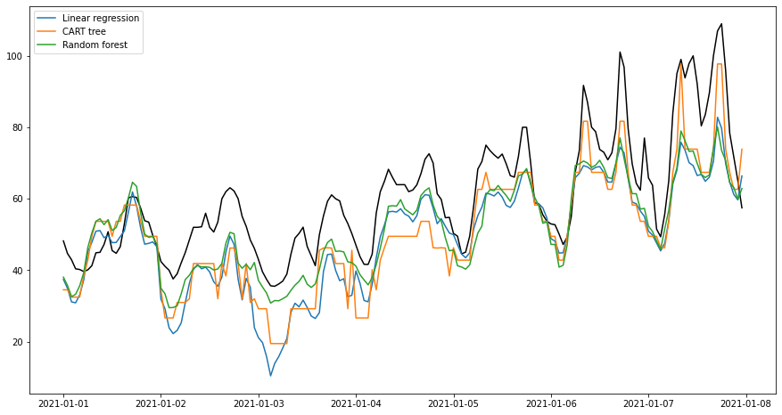

```python
fig, ax = plt.subplots(figsize=(15,8))
ax.plot(data_test.date[0:24*7], data_test.FR_SpotPrice[0:24*7], color='black')
ax.plot(data_test.date[0:24*7], lr_pred[0:24*7], label="Linear regression")
ax.plot(data_test.date[0:24*7], cart_pred[0:24*7], label="CART tree")
ax.plot(data_test.date[0:24*7], rf_pred[0:24*7], label="Random forest")
ax.legend()
plt.show()
```

**Q49** Let's cheat a bit: plot the prices in 2021.

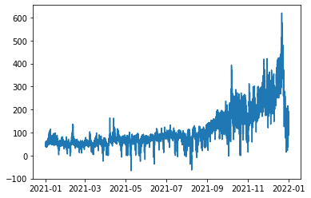

```python
plt.plot(data_test.date, data_test.FR_SpotPrice)
plt.show()
```

We can evaluate the evolution of our errors with time. To do so, implement a moving average average function that should average only around $w$ points symetrically distributed around each $x$.

**Q50** Create the moving average function.

*Tips: use convolve from numpy*

```python
def moving_average(x, w):
    return np.convolve(x, np.ones(w), 'valid') / w
```

**Q51** Apply this function on our errors (RMSE) with a window of size approximately one month. Plot these errors.

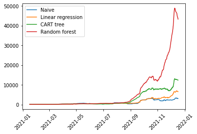

```python
h = 30
plt.plot(data_test.date[(np.int(h/2))*24:(data_test.shape[0]-(np.int(h/2))*24+1)],
         moving_average((Y_test-naive_pred)**2, h*24), label = 'Naive')
plt.plot(data_test.date[(np.int(h/2))*24:(data_test.shape[0]-(np.int(h/2))*24+1)],
         moving_average((Y_test-lr_pred)**2, h*24), label = 'Linear regression')
plt.plot(data_test.date[(np.int(h/2))*24:(data_test.shape[0]-(np.int(h/2))*24+1)],
         moving_average((Y_test-cart_pred)**2, h*24), label = 'CART tree')
plt.plot(data_test.date[(np.int(h/2))*24:(data_test.shape[0]-(np.int(h/2))*24+1)],
         moving_average((Y_test-rf_pred)**2, h*24), label = 'Random forest')
plt.legend()
plt.xticks(rotation=45)
plt.show()
```

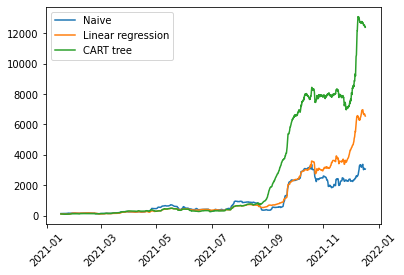

```python
h = 30
plt.plot(data_test.date[(np.int(h/2))*24:(data_test.shape[0]-(np.int(h/2))*24+1)],
         moving_average((Y_test-naive_pred)**2, h*24), label = 'Naive')
plt.plot(data_test.date[(np.int(h/2))*24:(data_test.shape[0]-(np.int(h/2))*24+1)],
         moving_average((Y_test-lr_pred)**2, h*24), label = 'Linear regression')
plt.plot(data_test.date[(np.int(h/2))*24:(data_test.shape[0]-(np.int(h/2))*24+1)],
         moving_average((Y_test-cart_pred)**2, h*24), label = 'CART tree')
plt.legend()
plt.xticks(rotation=45)
plt.show()
```

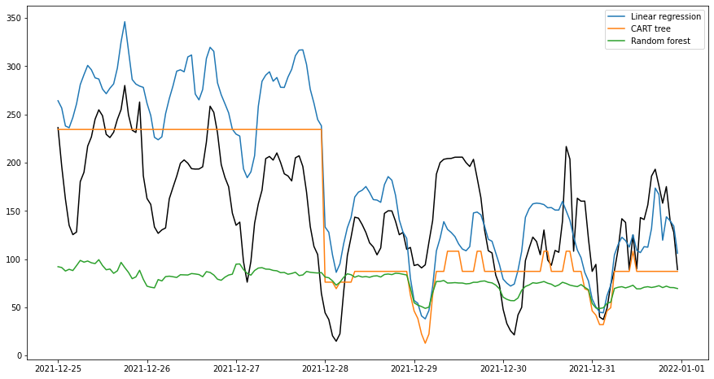

```python
fig, ax = plt.subplots(figsize=(15,8))
end = data_test.shape[0]
ax.plot(data_test.date[(end-24*7):end], data_test.FR_SpotPrice[(end-24*7):end], color='black')
ax.plot(data_test.date[(end-24*7):end], lr_pred[(end-24*7):end], label="Linear regression")
ax.plot(data_test.date[(end-24*7):end], cart_pred[(end-24*7):end], label="CART tree")
ax.plot(data_test.date[(end-24*7):end], rf_pred[(end-24*7):end], label="Random forest")
ax.legend()
plt.show()
```

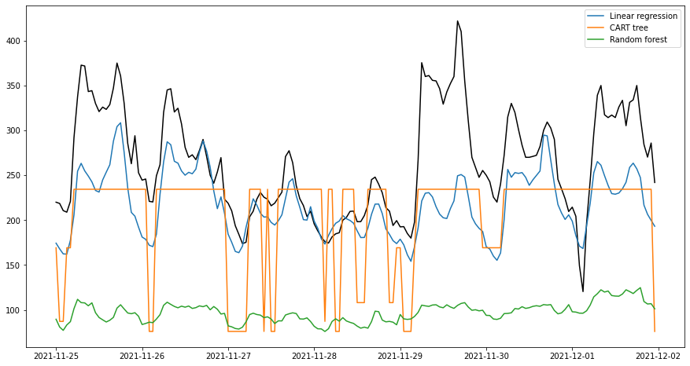

```python
fig, ax = plt.subplots(figsize=(15,8))
end = data_test.shape[0]
ax.plot(data_test.date[(end-24*37):(end-24*30)], data_test.FR_SpotPrice[(end-24*37):(end-24*30)], color='black')
ax.plot(data_test.date[(end-24*37):(end-24*30)], lr_pred[(end-24*37):(end-24*30)], label="Linear regression")
ax.plot(data_test.date[(end-24*37):(end-24*30)], cart_pred[(end-24*37):(end-24*30)], label="CART tree")
ax.plot(data_test.date[(end-24*37):(end-24*30)], rf_pred[(end-24*37):(end-24*30)], label="Random forest")
ax.legend()
plt.show()
```

**Q52** What can you propose as solution to improve the models?

### Growing window?

Back to table of contents.

```python
n_test = data_test.shape[0]

lr_pred = np.array([])
cart_pred = np.array([])
rf_pred = np.array([])
```

```python
from dateutil.relativedelta import relativedelta
```

```python
limit_train + relativedelta(months=0)
```

```
datetime.datetime(2020, 12, 31, 23, 0)
```

TQDM is a really useful package allowing you to monitor the time consumption of a loop, as well as its expected time before it finishes.

```python
from tqdm.autonotebook import tqdm
```

```python
for m in tqdm(range(12)):

    limit_train_window = limit_train + relativedelta(months=m)
    limit_test_window = limit_train + relativedelta(months=m+1)

    data_train = data.loc[data.date <= limit_train_window,:]
    data_train = data_train.drop(np.arange(168), axis=0) ## Initials NA because of lagged variables
    data_test = data.loc[(data.date > limit_train_window) & (data.date <= limit_test_window),:]
    X_train = data_train.iloc[:,2:data_train.shape[1]]
    Y_train = data_train.loc[:,'FR_SpotPrice']
    X_test = data_test.iloc[:,2:data_test.shape[1]]

    lr = LinearRegression()
    lr.fit(X_train, Y_train)
    cart_tree.fit(X_train, Y_train)
    rf.fit(X_train, Y_train)

    lr_pred = np.append(lr_pred, lr.predict(X_test))
    cart_pred = np.append(cart_pred, cart_tree.predict(X_test))
    rf_pred = np.append(rf_pred, rf.predict(X_test))
```

```python
print('Naive predictor')
regression_results(Y_test, naive_pred)
print('--------------')
print('Linear regression')
regression_results(Y_test, lr_pred)
print('--------------')
print('CART tree')
regression_results(Y_test, cart_pred)
print('--------------')
print('Random forest')
regression_results(Y_test, rf_pred)
```

```
Naive predictor
r2:  0.8564
MAE:  19.7378
RMSE:  31.9436
--------------
Linear regression
r2:  0.8639
MAE:  19.2557
RMSE:  31.0993
--------------
CART tree
r2:  0.7775
MAE:  24.3242
RMSE:  39.7649
--------------
Random forest
r2:  0.7824
MAE:  25.1229
RMSE:  39.3238
```

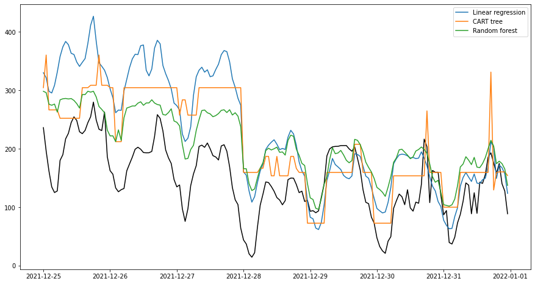

```python
limit_train = datetime.strptime('2020-12-31 23:00:00', "%Y-%m-%d %H:%M:%S")
limit_test = datetime.strptime('2021-12-31 23:00:00', "%Y-%m-%d %H:%M:%S")
data_train = data.loc[data.date <= limit_train,:]
data_test = data.loc[(data.date > limit_train) & (data.date <= limit_test),:]

fig, ax = plt.subplots(figsize=(15,8))
end = data_test.shape[0]
ax.plot(data_test.date[(end-24*7):end], data_test.FR_SpotPrice[(end-24*7):end], color='black')
ax.plot(data_test.date[(end-24*7):end], lr_pred[(end-24*7):end], label="Linear regression")
ax.plot(data_test.date[(end-24*7):end], cart_pred[(end-24*7):end], label="CART tree")
ax.plot(data_test.date[(end-24*7):end], rf_pred[(end-24*7):end], label="Random forest")
ax.legend()
plt.show()
```

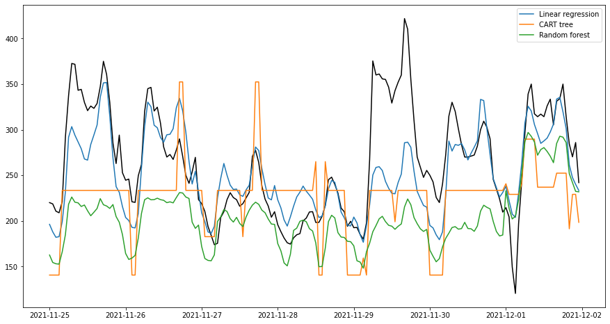

```python
fig, ax = plt.subplots(figsize=(15,8))
end = data_test.shape[0]
ax.plot(data_test.date[(end-24*37):(end-24*30)], data_test.FR_SpotPrice[(end-24*37):(end-24*30)], color='black')
ax.plot(data_test.date[(end-24*37):(end-24*30)], lr_pred[(end-24*37):(end-24*30)], label="Linear regression")
ax.plot(data_test.date[(end-24*37):(end-24*30)], cart_pred[(end-24*37):(end-24*30)], label="CART tree")
ax.plot(data_test.date[(end-24*37):(end-24*30)], rf_pred[(end-24*37):(end-24*30)], label="Random forest")
ax.legend()
plt.show()
```

We have managed to improve our performances, and beat our naive predictor.

# References

Some references to go further on the topic:

[*Electricity price forecasting: A review of the state-of-the-art with a look into the future*](https://www.sciencedirect.com/science/article/pii/S0169207014001083)  
Weron, 2014, **International Journal of Forecasting**

[*Forecasting day-ahead electricity prices: A review of state-of-the-art algorithms, best practices and an open-access benchmark*](https://arxiv.org/abs/2008.08004)  
Lago et al., 2021, **Applied Energy**

Back to table of contents.